# FigureYa50ChinaMap

Jie Zhang; Ying Ge, Yijing Chen

2025-5-20

[figure not shown]

# 需求描述

# requirement description

世界地图上的中国标准地图，省份内填充的颜色展示该省数据。

A standard map of China on the world map, with colors filled within each province to represent the data of that province.

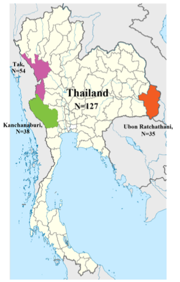

出自http://dx.plos.org/10.1371/journal.pntd.0005930

fromhttp://dx.plos.org/10.1371/journal.pntd.0005930

# 应用场景

# application scenario

展示某一特征值在各省的分布情况。例如：人口、发病率、GDP等。

Display the distribution of a specific characteristic across provinces. For example: population, incidence rate, GDP, etc.

# 环境设置

# environment setting

用国内清华的镜像安装包，更快

Use the domestic Tsinghua’s mirror installation package, faster

```r
options("repos"= c(CRAN="https://mirrors.tuna.tsinghua.edu.cn/CRAN/"))
install.packages("Cairo")
install.packages('pinyin')
```

加载R包

load R package

```r
library(pinyin) #汉字转拼音 convert Chinese characters to pinyin
library(maps)
library(ggplot2)
library(scales)
library(plyr)
library(Cairo)
library(maptools)
library(sf)
library(dplyr)
library(stringr)

Sys.setenv(LANGUAGE = "en") #显示英文报错信息 display English error messages
options(stringsAsFactors = FALSE) #禁止chr转成factor prohibit the conversion of chr to factor
```

# 输入数据

# Input data

easy_input.csv，要画的各省数据。包含两列：省的名字和数值

easy_input.csv, data of each province to be plotted. It contains two columns: the name and value of the province

```r
mydata <- read.csv("easy_input.csv")
head(mydata)
```

```
##    province Value
## 1     anhui    24
## 2   beijing   290
## 3 diaoyudao     7
## 4    fujian   112
## 5     gansu    27
## 6 guangdong   355
```

# 导入地图数据，并编辑

# Import map data and edit

bou2_4m文件夹，中国省级地图文件，比例尺为400万分之一。来源于国家基础地理信息中心的网站http://nfgis.nsdi.gov.cn，里面的省名是GBK编码的汉字。

字母p结尾的表示多边形数据，用来绘制区域；字母l结尾的文件是线形数据，用来绘制边界。

bou2_4m folder, Chinese provincial map files with scale of 1:4,000,000. Sourced from the website of the National Geomatics Center of China http://nfgis.nsdi.gov.cn, the province names in it are GBK-encoded Chinese characters.

Files ending with the letter p represent polygonal data, which are used to draw areas; files ending with the letter l are linear data, which are used to draw boundaries.

```r
world_map <- map_data("world")

#边界线
#boundary line
china_map <- st_read("bou2_4m/bou2_4l.shp")
xs <- china_map %>%
  as.data.frame() %>%
  mutate(id = row.names(.))
china_line_data <- china_map %>%
  st_as_sf() %>%
  mutate(id = row.names(.)) %>%
  left_join(xs, by = "id")

#省级区域地图
#map of provincial areas
china_map <- st_read("bou2_4m/bou2_4p.shp")
xs <- china_map %>%
  st_drop_geometry() %>%
  mutate(id = row.names(.))

#把省名从GBK转成UTF-8
#convert province name from GBK to UTF-8
xs$NAME <- iconv(xs$NAME, from = "GBK", to = "UTF-8")
#把省名从汉字转成拼音
#convert province name from Chinese characters to pinyin
pinyinProv <- data.frame(NAME = unique(xs$NAME),
                         province = apply(data.frame(unique(xs$NAME), stringsAsFactors = F),1,
                                        function(x)(py(x, sep = "", dic = pydic(method = "toneless", dic = "pinyin2")))))
#删掉sheng、zizhiqu、huizuzizhiqu、weiwuerzizhiqu、zhuangzuzizhiqu、tebiehangzhengqu字样
#delete the words sheng, zizhiqu, huizuzizhiqu, weiwuerzizhiqu, zhuangzuzizhiqu, tebiehangzhengqu
pinyinProv$province <- str_replace_all(pinyinProv$province, "sheng","")
pinyinProv$province <- str_replace_all(pinyinProv$province, "shi","")
pinyinProv$province <- str_replace_all(pinyinProv$province, "huizuzizhiqu","")
pinyinProv$province <- str_replace_all(pinyinProv$province, "weiwuerzizhiqu","")
pinyinProv$province <- str_replace_all(pinyinProv$province, "zhuangzuzizhiqu","")
pinyinProv$province <- str_replace_all(pinyinProv$province, "tebiehangzhengqu","")
pinyinProv$province <- str_replace_all(pinyinProv$province, "zizhiqu","")
#把陕西跟山西的拼音区分开，陕西的拼音是shannxi
#differentiate the pinyin of Shaanxi and Shanxi, the pinyin for Shaanxi is shannxi.
pinyinProv[11,]$province <- "shannxi"

#把拼音合并进地图文件
#merge pinyin into a map file
xss <- left_join(xs, pinyinProv, by = "NAME")

#提取经纬度
#extract latitude and longitude
china_map_data <- china_map %>%
  mutate(id = row.names(.)) %>%
  left_join(xss, by = "id")
```

# 南海方框内地图的计算

# Calculation of the map within the South China Sea box

```r
#参数设置
#parameter setting
Width<-8
Height<-9

#方框的位置
#position of the box
long_Start<-128
lat_Start<-18

#南海方框内要画的经纬度范围
#the latitude and longitude ranges to be drawn in the South China Sea box
china_line_data <- st_make_valid(china_line_data)
china_map_data <- st_make_valid(china_map_data)

suppressWarnings({
  bbox <- st_bbox(c(xmin = 106.55, xmax = 123.58, ymin = 4.61, ymax = 25.45),
                 crs = st_crs(china_line_data))
  china_map1 <- st_crop(china_line_data, bbox)
  china_map2 <- st_crop(china_map_data, bbox)
})

#缩小后的经纬度
#reduced latitude and longitude
scale_geometry <- function(geom) {
  if (is.na(st_dimension(geom))) return(geom)

  coords <- st_coordinates(geom)
  scaled_coords <- coords
  scaled_coords[, "X"] <- (coords[, "X"] - bbox_origin["xmin"]) / x_range * Width + long_Start
  scaled_coords[, "Y"] <- (coords[, "Y"] - bbox_origin["ymin"]) / y_range * Height + lat_Start

  geom_type <- st_geometry_type(geom)

  if (geom_type %in% c("LINESTRING", "MULTILINESTRING")) {
    if ("L1" %in% colnames(coords)) {
      parts <- split(as.data.frame(scaled_coords), list(coords[, "L1"]))
      lines <- lapply(parts, function(p) as.matrix(p[, c("X", "Y")]))
      if (length(lines) > 1) st_multilinestring(lines) else st_linestring(lines[[1]])
    } else {
      st_linestring(scaled_coords[, c("X", "Y")])
    }
  } else if (geom_type %in% c("POLYGON", "MULTIPOLYGON")) {
    if ("L1" %in% colnames(coords)) {
      close_ring <- function(m) {
        if (!all(m[1, ] == m[nrow(m), ])) rbind(m, m[1, , drop = FALSE]) else m
      }

      parts <- split(as.data.frame(scaled_coords), list(coords[, "L2"], coords[, "L1"]))
      polygons <- lapply(parts, function(p) close_ring(as.matrix(p[, c("X", "Y")])))

      if (length(polygons) > 1) {
        st_multipolygon(list(polygons))
      } else {
        st_polygon(list(polygons[[1]]))
      }
    } else {
      closed <- if (!all(scaled_coords[1, 1:2] == scaled_coords[nrow(scaled_coords), 1:2])) {
        rbind(scaled_coords[, 1:2], scaled_coords[1, 1:2])
      } else {
        scaled_coords[, 1:2]
      }
      st_polygon(list(closed))
    }
  } else {
    warning("未处理的几何类型: ", geom_type)
    geom
  }
}

bbox_origin <- st_bbox(china_map2)
x_range <- bbox_origin["xmax"] - bbox_origin["xmin"]
y_range <- bbox_origin["ymax"] - bbox_origin["ymin"]

china_map3 <- china_map1
st_geometry(china_map3) <- st_sfc(lapply(st_geometry(china_map1), scale_geometry),
                                 crs = st_crs(china_map1))

china_map4 <- china_map2
st_geometry(china_map4) <- st_sfc(lapply(st_geometry(china_map2), scale_geometry),
                                 crs = st_crs(china_map2))
```

# 开始画图

# Start drawing

```r
#地图跟各省数据value合并
#merge the map with the value data of each province
china_data <- merge(china_map_data, mydata, all = TRUE)
china_map4 <- merge(china_map4, mydata, all = TRUE)

#保存到pdf文件
#save to PDF file
CairoPDF(file="China_map",width=6.14*2,height=3.22*2)
p <- ggplot() +
  #先画世界地图作为背景，后面画的就是往它上面叠加
  #first, draw the world map as the background, and then overlay the subsequent drawings on top of it
  geom_polygon(data=world_map,
               aes(x=long,y=lat,group=group),
               colour="grey20", #边界线深灰色 boundary line dark gray
               fill="#EAEAEA", #浅灰色填充 light gray filling
               size=.1)+

  #边界线黑色
  #boundary line black
  geom_sf(data = china_line_data,
          color = "black", linewidth = 0.15) +

  #自定义填充色
  #custom fill colors
  scale_fill_gradient(low = "white", high = "#92150C", #渐变色 gradient color
                      na.value = "#FEFFE8") + #没有值的省用黄色填充 provisions with no value are filled in yellow

  #省份区域颜色填充
  #province area color fill
  geom_sf(data = china_data,
          aes(fill = Value),  #或as.factor(Value)设置单个的颜色 or set a single color using as.factor(Value)
          color = "grey10", linewidth = 0.1) +

  #南海边框
  #South China Sea border
  geom_rect(aes(xmin = long_Start, xmax = long_Start + Width,
                ymin = lat_Start, ymax = lat_Start + Height),
            fill = NA, color = "black", linewidth = 0.15) +

  #南海方框内的省份颜色填充
  #color fill of provinces in the South China Sea box
  geom_sf(data = china_map4,
          aes(fill = Value),
          color = "grey10", linewidth = 0.05) +

  #南海方框内的边界线
  #boundary lines in the South China Sea box
  geom_sf(data = china_map3,
          color = "black", linewidth = 0.05) +

  coord_sf() +
  theme_void() + #不画坐标系 do not draw coordinate system
  theme(plot.background = element_rect(fill = "lightskyblue")) #海水蓝色 seawater blue
p
dev.off()
```

# 后期处理

# Post-processing

输出的pdf文件是矢量图，可以在Illustrator等软件里打开，截取想要的区域即可。例如：

The output pdf file is a vector map, you can open in Illustrator and other software, intercept the desired area. For example:

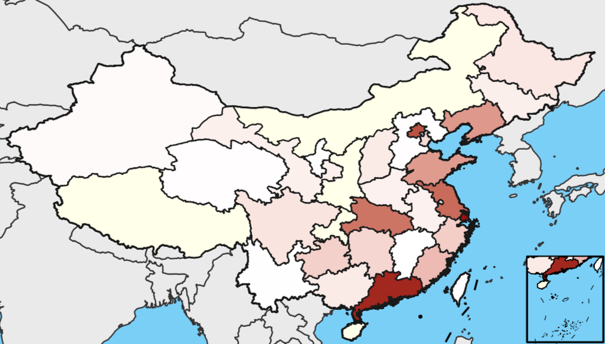